# Stats 250: Lab 8 Assignment

Elan Grossman

2023-11-16

### Instructions

Complete the lab exercises and Dive Deeper questions below. Lab exercises will be graded out of 2 points each and the Dive Deeper questions will be graded out of 3 points each - all of them will be graded for *correctness*. Upon completion, follow the submission instructions at the bottom of this document. We strongly encourage you to work on this assignment with a partner, but each student must submit their own lab assignment.

### Background

The common cuckoo does not build its own nest: it prefers to lay its eggs in another birds’ nest. It is known that the type of cuckoo bird eggs are different between different locations. In a study from 1940, it was shown that cuckoos return to the same nesting area each year, and that they always pick the same bird species to be a “foster parent” for their eggs.

Over the years, this has lead to the development of geographically determined subspecies of cuckoos. These subspecies have evolved in such a way that their eggs look as similar as possible as those of their foster parents.

The `cuckoo` data set contains information on a *sample* of 120 Cuckoo eggs, obtained from randomly selected “foster” nests. For these eggs, researchers have recorded:

- `length`: the length of the egg (in mm)
- `breadth`: the breadth of the egg (in mm)
- `species`: the species of the “foster parent” ((1) hedge sparrow, (2) meadow pipit, (3) pied wagtail, (4) robin, (5) tree pipit, and (6) wren)

**Goal:** We wish to determine if the type of foster parent (i.e., the species) has an effect on the average length of the cuckoo egg.

If you’re interested to read more about this unique bird, head to the link below!

[Cuckoo! Cuckoo!](https://archive.nytimes.com/opinionator.blogs.nytimes.com/2010/06/01/cuckoo-cuckoo/)

Run the code chunk below to read in the data.

```r
cuckoo <- read.csv("cuckoo_eggs.csv")
```

You can preview the data here.

```r
head(cuckoo)
```

```
##   length breadth      species
## 1   21.7    16.1 meadow.pipit
## 2   22.6    17.0 meadow.pipit
## 3   20.9    16.2 meadow.pipit
## 4   21.6    16.2 meadow.pipit
## 5   22.2    16.9 meadow.pipit
## 6   22.5    16.9 meadow.pipit
```

And be sure to load in the required packages!

```r
library(ggplot2)
```

### Lab Exercises

After reading the background above, complete the following lab exercises. Remember, these exercises are worth 2 points each and are graded for *correctness*.

> **1.** After reading the full background above, identify the variable roles and variable types for our two variables of interest.

*Response Variable:* Length. This variable is quantitative.

*Explanatory Variable:* Type of foster parent (species). This variable is categorical.

> **2.** The null hypothesis for the intended analysis can be found below - where the subscripts correspond to the following: (1) hedge sparrow, (2) meadow pipit, (3) pied wagtail, (4) robin, (5) tree pipit, and (6) wren. First, write the alternative hypothesis. Then, define mu1 from the null hypothesis *in context*.

*H0:* mu1 = mu2 = mu3 = mu4 = mu5 = mu6

*Ha:* At least one mu is different than the others.

*Parameter Definition:* Where mu1 represents the true mean length of hedge sparrow egg.

> **3.** Use the `aggregate()` function to compute the mean egg length for each type of foster parent. Briefly comment on if there appear to be any differences between the computed means.

```r
aggregate(length ~ species,
          data = cuckoo,
          FUN = mean)
```

```
##         species   length
## 1 hedge.sparrow 23.11429
## 2  meadow.pipit 22.29333
## 3  pied.wagtail 22.88667
## 4         robin 22.55625
## 5    tree.pipit 23.08000
## 6          wren 21.12000
```

*Answer:* After looking at the mean lengths of all the species eggs, it is noted that they are all slightly different from one another. Ranging from approximately 21-23 mm.

> **4.** Using `ggplot()`, create a side-by-side boxplot for the analysis. Include points for the means of each group. As always, be sure to give your plot an appropriate title and axis labels. Briefly comment on if there appear to be any differences in egg length between the various foster parents (species).

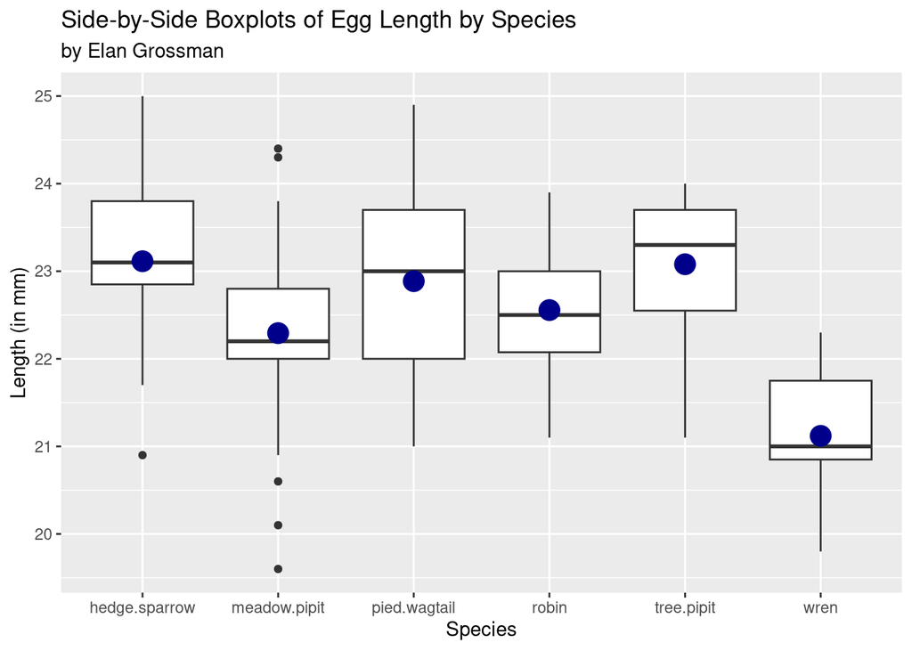

```r
ggplot(data = cuckoo, aes(x = species, y = length)) +

  geom_boxplot() +

  labs(title = "Side-by-Side Boxplots of Egg Length by Species",
       subtitle = "by Elan Grossman",
       x = "Species",
       y = "Length (in mm)") +

  stat_summary(fun = mean, geom = "point", size = 5, color = "darkblue")
```

> **5.** Using `ggplot()`, create a side-by-side boxplot for the analysis. Include points for the means of each group. *Add dot plots to the graph.* Play around with the `size`, `color`, and `dotsize` components of your code. As always, be sure to give your plot an appropriate title and axis labels.

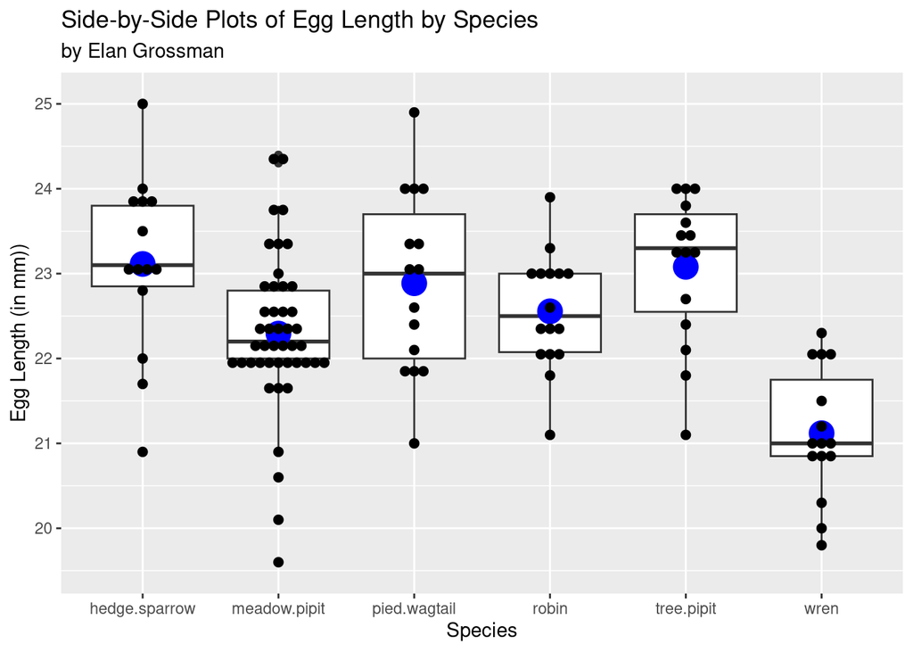

```r
ggplot(data = cuckoo, aes(x = species, y = length)) +

  geom_boxplot() +

  stat_summary(fun = mean, geom = "point", size = 6, color = "blue")+

  geom_dotplot(binaxis = "y", stackdir = "center", dotsize = 0.6)  +

  labs(title = "Side-by-Side Plots of Egg Length by Species",
       subtitle = "by Elan Grossman",
       x = "Species",
       y = "Egg Length (in mm))")
```

> **6.** Run the ANOVA using R. Evaluate the p-value by selecting one of the options below. What conclusion can be drawn from this p-value? Be sure to incude context with your conclusion!

```r
summary(aov(formula = length ~ species, data = cuckoo))
```

```
##              Df Sum Sq Mean Sq F value   Pr(>F)
## species       5  42.81   8.562   10.45 2.85e-08 ***
## Residuals   114  93.41   0.819
## ---
## Signif. codes:  0 '***' 0.001 '**' 0.01 '*' 0.05 '.' 0.1 ' ' 1
```

*Evaluation:* The p-value above provides very strong evidence against the null hypothesis and in favor of the alternative hypothesis.

*Conclusion:* From the results of our ANOVA, our data suggests that at least one of the species has a different average egg length size.

> **7.** Run a follow-up analysis using Tukey’s procedure. Identify *at least two pairs* of species where the data suggests that a difference in average egg length exists. Note: plotting the data isn’t very helpful here because there are too many comparisons for the size of the plotting window.

```r
TukeyHSD(aov(formula = length ~ species, data = cuckoo))
```

```
##   Tukey multiple comparisons of means
##     95% family-wise confidence level
##
## Fit: aov(formula = length ~ species, data = cuckoo)
##
## $species
##                                   diff          lwr         upr     p adj
## meadow.pipit-hedge.sparrow -0.82095238 -1.623950281 -0.01795448 0.0419956
## pied.wagtail-hedge.sparrow -0.22761905 -1.202716519  0.74747842 0.9841852
## robin-hedge.sparrow        -0.55803571 -1.518309994  0.40223857 0.5447831
## tree.pipit-hedge.sparrow   -0.03428571 -1.009383185  0.94081176 0.9999984
## wren-hedge.sparrow         -1.99428571 -2.969383185 -1.01918824 0.0000005
## pied.wagtail-meadow.pipit   0.59333333 -0.188983035  1.37564970 0.2465807
## robin-meadow.pipit          0.26291667 -0.500844104  1.02667744 0.9177494
## tree.pipit-meadow.pipit     0.78666667  0.004350298  1.56898304 0.0478958
## wren-meadow.pipit          -1.17333333 -1.955649702 -0.39101696 0.0004239
## robin-pied.wagtail         -0.33041667 -1.273464897  0.61263156 0.9118539
## tree.pipit-pied.wagtail     0.19333333 -0.764804627  1.15147129 0.9918559
## wren-pied.wagtail          -1.76666667 -2.724804627 -0.80852871 0.0000069
## tree.pipit-robin            0.52375000 -0.419298231  1.46679823 0.5937631
## wren-robin                 -1.43625000 -2.379298231 -0.49320177 0.0003272
## wren-tree.pipit            -1.96000000 -2.918137960 -1.00186204 0.0000005
```

*Pair #1:* Pair #1: meadow.pipit - hedge.sparrow

*Pair #2:* tree.pipit - meadow.pipit

### Dive Deeper Questions

After completing the lab exercises above, complete the following Dive Deeper questions. Remember, these questions are worth 3 points each and are graded for correctness.

> **1.** Suppose that all of the measurements for the eggs from *wren* foster parents were misrecorded. The actual lengths of all eggs from wren foster parents should be 1 mm *longer*. If we reran the ANOVA (with the correct measurements), would the value of the F test statistic increase, decrease, or stay the same. Explain your answer.

*Answer*: Because we increased all the lengths by 1mm, the variability within the group stays the same but between the group decreases. If the differences between the groups means are large relative to the response differences within the groups, the numerator of the F statistic is larger than the denominator, and the F statistic is large.

> **2.** Suppose the original cuckoo data set only contained the observations of three species (the three specific species are not specified here). The plot from Tukey’s follow-up analysis is provided below. Given this plot, what do you think the value of the p-value was for the corresponding ANOVA for these three species? Your options include: greater than 0.10, between 0.10 and 0.05, between 0.05 and 0.01, and less than 0.01. Explain your answer.

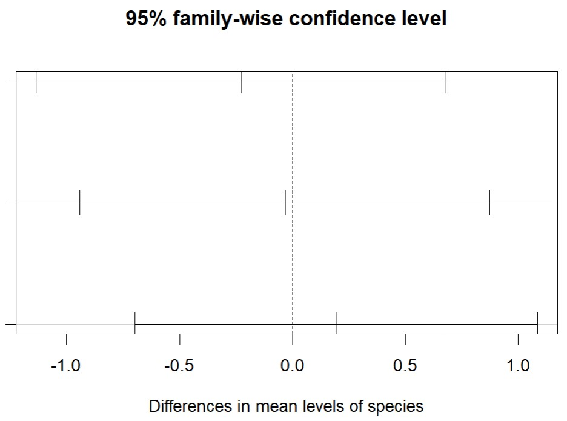

*Answer:* The p value from the ANOVA test is greater than 0.1. This is because all of the confidence intervals contain 0 which indicates we do not have enough evidence to suggest at least one species has a different mean egg length.

### Submission Instructions

Once you have finished, follow the instructions below to submit your work.

1. At the top of the document, update the `author` field. *Do not change anything else at the top of the document.*
2. Click the Knit button to create an HTML file of your work.
3. In the Files pane (bottom right window), check the box next to `lab08_assignment.html`.
4. In the Files pane, click on the gear icon (More) and select “Export…”
5. Do not change the file name (`lab08_assignment.html`). Click Download and save the file to your computer.
6. On the Stats 250 Canvas site, navigate to the Lab 8 assignment.
7. Upload your saved `lab08_assignment.html` file.
8. Click “Submit Assignment”. Congratulations, you are done with Lab 8!